[figure not shown]

A package of R markdown templates.

These are a set of alternate R markdown templates that do not use Bootstrap and do not include or rely on jQuery. These are primarily here for demonstration purposes but are also useful in and of themselves (it’s always good to have choices). If you have a particular framework you like and it’s not here, file an issue and I’ll add it.

- **bulma** (`output: USGSmarkdowntemplates::bulma`) uses the [Bulma CSS framework](http://bulma.io) and has optional `navlink` YAML header elements and also has support for arbitrary footer content & a subset of OpenGraph tags (see the example Rmd) which will be used in header of the generated file.
- **skeleton** (`output: USGSmarkdowntemplates::skeleton`) or **default** (`output: USGSmarkdowntemplates::default`) uses the [Skeleton CSS framework](http://getskeleton.com) and has optional `navlink` YAML header elements and also has support for arbitrary footer content & a subset of OpenGraph tags (see the example Rmd) which will be used in header of the generated file.
- **kube** (`output: USGSmarkdowntemplates::kube`) uses the [Kube CSS framework](https://imperavi.com/kube/) (contributed by Kieran Healy)
- **minimal** (`output: USGSmarkdowntemplates::minimal`) uses no CSS framework and only uses the `title` YAML header element.
- **hugo** (`output: USGSmarkdowntemplates::hugo`) produces markdown suitable for [Hugo](https://gohugo.io/) websites. It makes a broad assumption that you will save/use the `hugo` document in the `content` directory of your Hugo websites.

When you use RStudio to create a new R Markdown document, select “From Template” and choose one of these templates.

### Installation

Since the package is not on CRAN yet, you have to install it from GitHub.

```
if (!("devtools" %in% installed.packages())){
  install.packages("devtools")
}

devtools::install_github("hrbrmstr/USGSmarkdowntemplates")
```

### Releases

- 0.3.4.9000 TOC basic formattingin Bulma (and re-enabled TOC in general)
- 0.3.3.9000 Replicate Bulma functionality in Skeleton/default; added supported YAML frontmatter to template functions docs
- 0.3.2.9000 Basic template tests; `rmarkdown::render` examples added to template functions
- 0.3.1.9000 Passes CRAN checks
- 0.3.0.9000 Kube framework contributed by Kieran Healy; preview images in help pages
- 0.2.1.9000 arbitrary footer content can be specified in the YAML header
- 0.2.0.9000 `self_contained=FALSE` now copies the custom CSS
- 0.1.0.9000 Initial release

### Bulma example

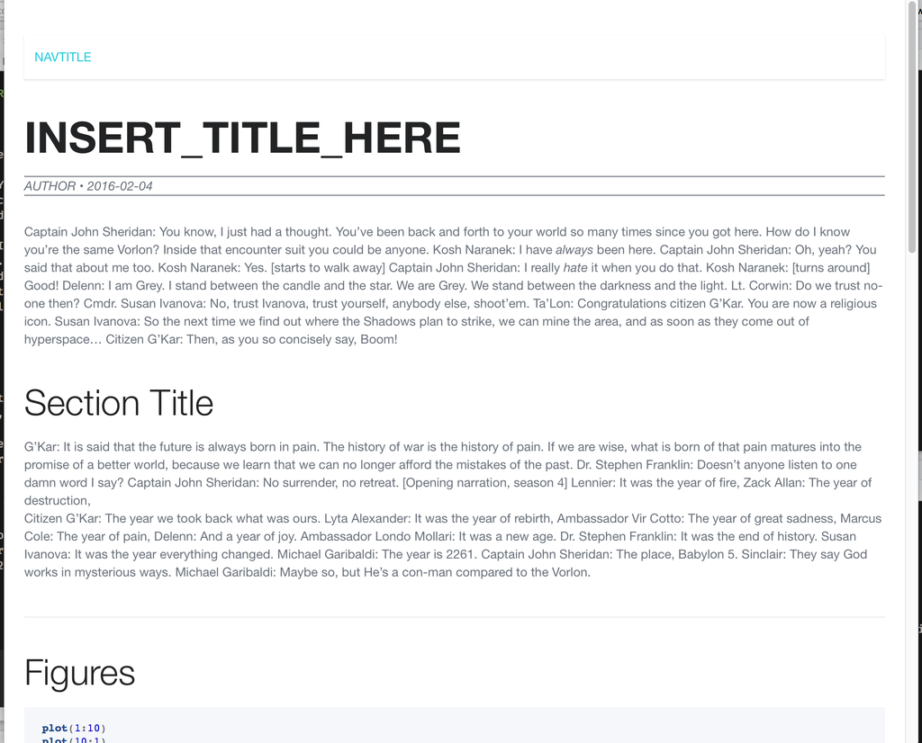

### Skeleton/default example

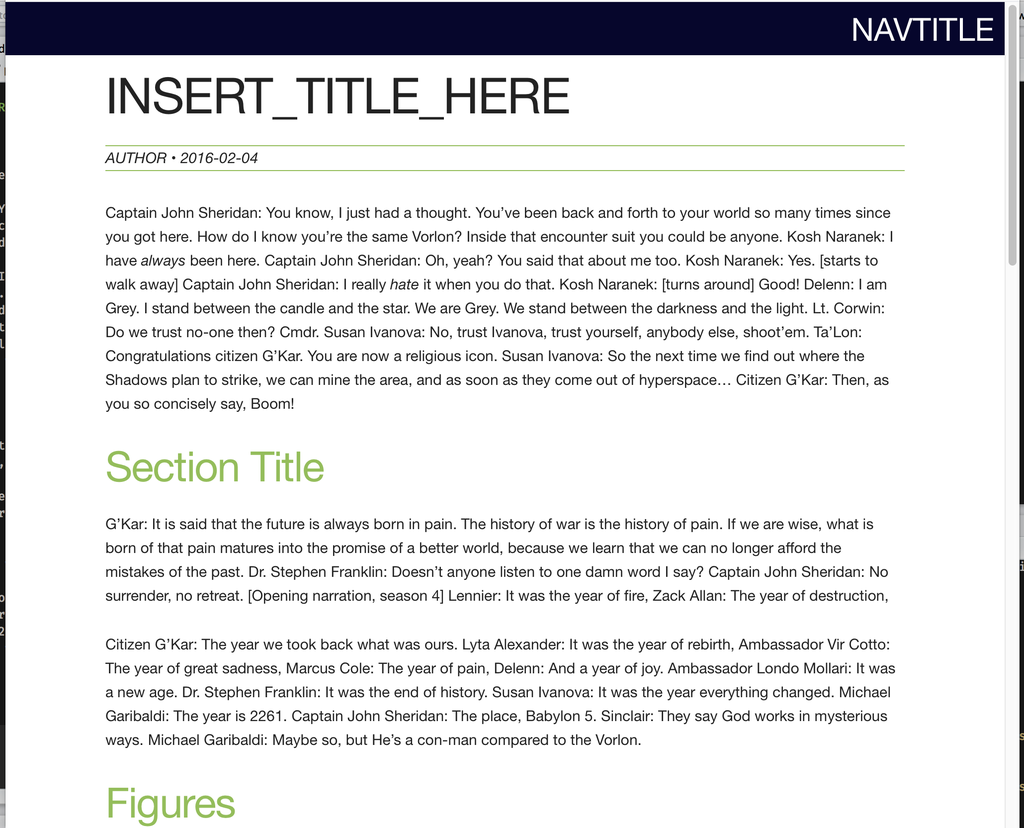

### Kube example

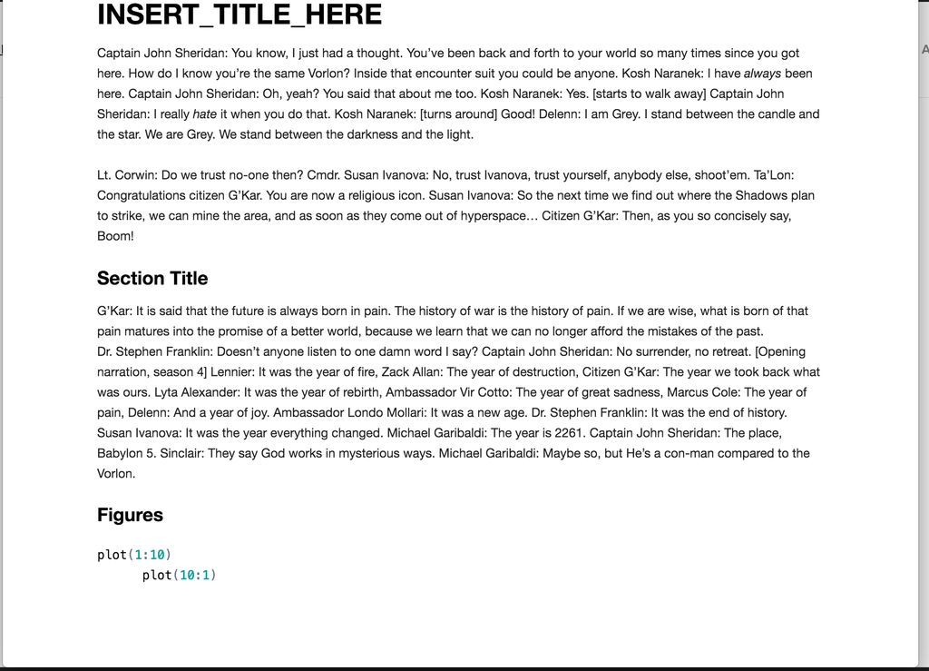

### Minimal example

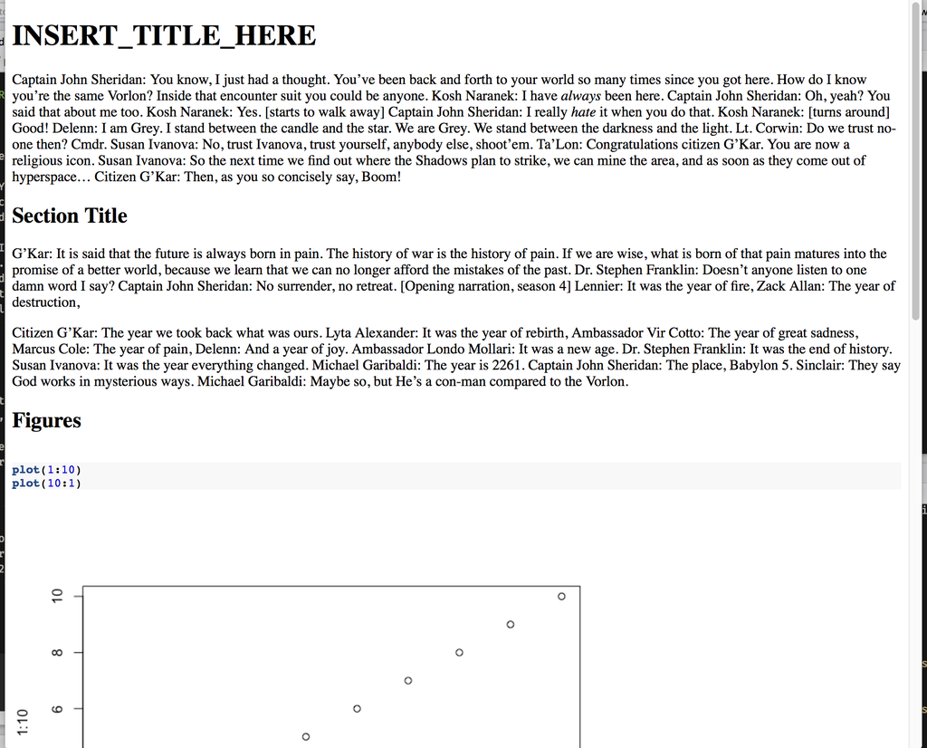